# fraude financiero

# Matriz Missing

Matrix missing: Mostramos una matriz de calor para visualizar las variables con mayor presencia de valores perdidos. Las líneas blancas indican los valores faltantes en cada columna.

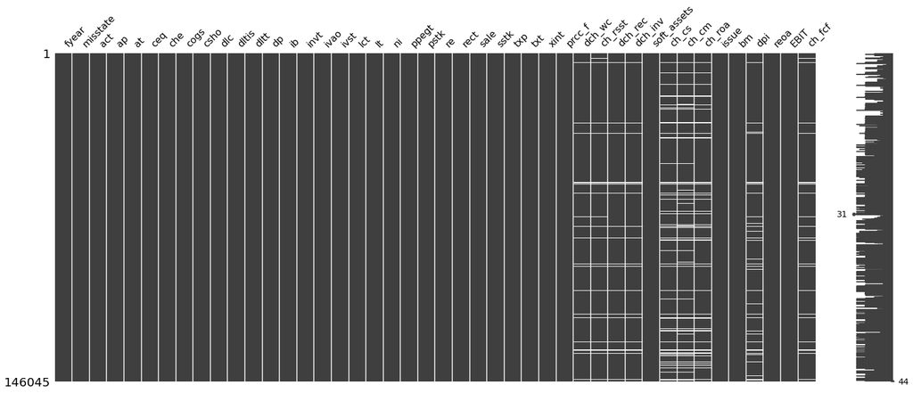

```python
# matrix missing
msno.matrix(data)
```

heatmap missing cor: El mapa de calor muestra una correlación positiva con el azul. Cuanto más oscuro sea el tono de azul, mayor será la correlación.

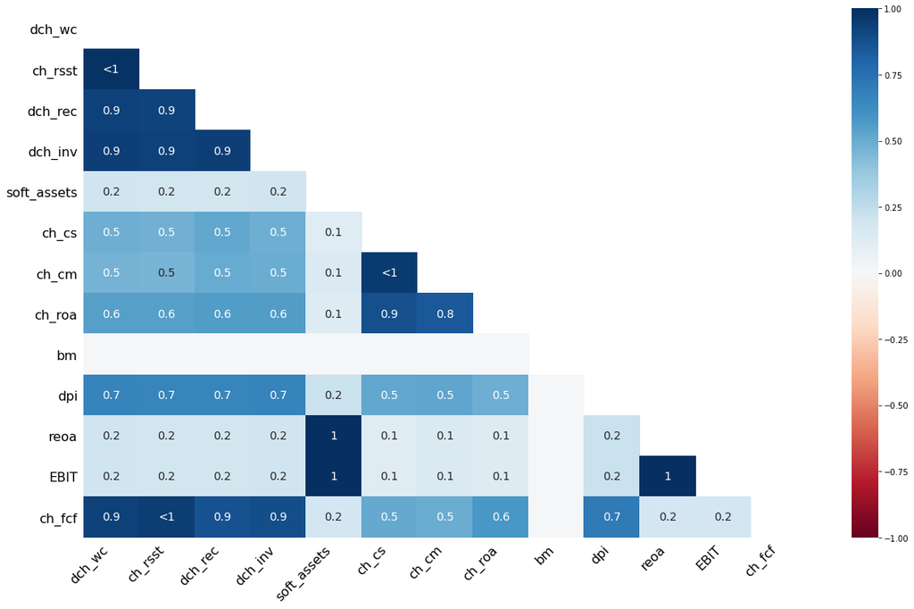

```python
# heatmap missing
msno.heatmap(data)
```

bar missing: Otra forma de visualizar los datos de los valores perdidos es mediante el uso de gráficos de barras. Estas barras muestran los valores que son proporcionales a los datos que no faltan en el conjunto de datos. Junto con eso, también se muestra el número de valores que faltan.

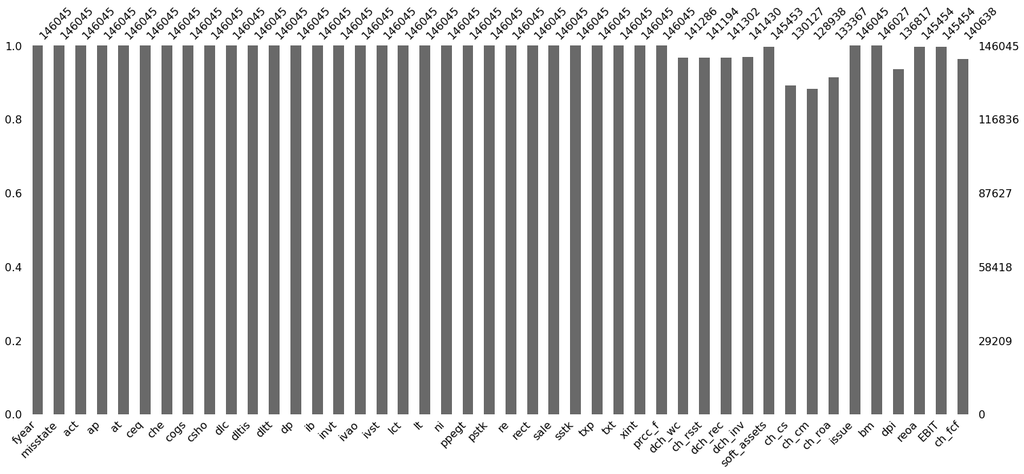

```python
# bar missing
msno.bar(data)
```

# Técnicas de imputación de datos

Métodos de imputación: Media o mediana u otra sustitución estadística de resumen.

```python
from sklearn.impute import SimpleImputer

# Define las columnas que tienen valores perdidos que deseas imputar
# Reemplaza 'columna1', 'columna2', ... con los nombres de tus columnas
columnas_a_imputar = ['dch_wc', 'ch_rsst', 'dch_rec', 'dch_inv', 'ch_cs', 'ch_cm', 'ch_roa', 'bm', 'reoa', 'EBIT', 'ch_fcf', 'soft_assets', 'dpi']

# Crea un objeto SimpleImputer para imputar por la mediana
imputer = SimpleImputer(strategy='median')

# Aplica la imputación a las columnas seleccionadas
data[columnas_a_imputar] = imputer.fit_transform(data[columnas_a_imputar])

# Ahora, df contiene los datos con valores perdidos imputados por la mediana
# Puedes guardar este DataFrame en un nuevo archivo si lo deseas
# df.to_csv('data_imputado.csv', index=False)
```

```python
# Después de la imputación
print(data[columnas_a_imputar].isnull().sum())
```

```
dch_wc         0
ch_rsst        0
dch_rec        0
dch_inv        0
ch_cs          0
ch_cm          0
ch_roa         0
bm             0
reoa           0
EBIT           0
ch_fcf         0
soft_assets    0
dpi            0
dtype: int64
```

```python
# explorando la cantidad de valores perdidos en las variables
data.isna().sum()/data.shape[0]*100
```

```
fyear          0.0
misstate       0.0
act            0.0
ap             0.0
at             0.0
ceq            0.0
che            0.0
cogs           0.0
csho           0.0
dlc            0.0
dltis          0.0
dltt           0.0
dp             0.0
ib             0.0
invt           0.0
ivao           0.0
ivst           0.0
lct            0.0
lt             0.0
ni             0.0
ppegt          0.0
pstk           0.0
re             0.0
rect           0.0
sale           0.0
sstk           0.0
txp            0.0
txt            0.0
xint           0.0
prcc_f         0.0
dch_wc         0.0
ch_rsst        0.0
dch_rec        0.0
dch_inv        0.0
soft_assets    0.0
ch_cs          0.0
ch_cm          0.0
ch_roa         0.0
issue          0.0
bm             0.0
dpi            0.0
reoa           0.0
EBIT           0.0
ch_fcf         0.0
dtype: float64
```

```python
# Itera a través de las columnas del DataFrame y verifica el equilibrio
for columna in data.columns:
    if data[columna].dtype == 'object':
        # Si es una variable categórica, verifica el equilibrio de las categorías
        counts = data[columna].value_counts()
        print(f"Variable categórica: {columna}")
        print(counts)
    elif data[columna].dtype in ['int64', 'float64']:
        # Si es una variable numérica, puedes calcular estadísticas descriptivas
        descripcion = data[columna].describe()
        print(f"Variable numérica: {columna}")
        print(descripcion)
    print('-' * 40)
```

```
Variable numérica: fyear
count    146045.000000
mean       2002.011702
std           6.959894
min        1990.000000
25%        1996.000000
50%        2002.000000
75%        2008.000000
max        2014.000000
Name: fyear, dtype: float64
----------------------------------------
Variable numérica: misstate
count    146045.000000
mean          0.006601
std           0.080976
min           0.000000
25%           0.000000
50%           0.000000
75%           0.000000
max           1.000000
Name: misstate, dtype: float64
----------------------------------------
Variable numérica: act
count    146045.000000
mean        737.847759
std        3744.542368
min          -0.254000
25%           8.277000
50%          47.501000
75%         249.832000
max      152629.000000
Name: act, dtype: float64
----------------------------------------
Variable numérica: ap
count    146045.000000
mean        181.993488
std        1047.546104
min           0.000000
25%           1.151000
50%           6.462000
```

[output cut: 429 more lines]

```
75%           0.107747
max           0.550619
Name: EBIT, dtype: float64
----------------------------------------
Variable numérica: ch_fcf
count    146045.000000
mean         -0.009483
std           0.537982
min          -2.980601
25%          -0.116775
50%          -0.026155
75%           0.055781
max           4.061810
Name: ch_fcf, dtype: float64
----------------------------------------
```

# Mezclar el dataset

```python
#Mezclar el dataset
data = data.sample(frac=1).reset_index(drop=True)
data.head(10)
```

|  | fyear | misstate | act | ap | at | ceq | che | cogs | csho | dlc | ... | soft_assets | ch_cs | ch_cm | ch_roa | issue | bm | dpi | reoa | EBIT | ch_fcf |
| --- | --- | --- | --- | --- | --- | --- | --- | --- | --- | --- | --- | --- | --- | --- | --- | --- | --- | --- | --- | --- | --- |
| 0 | 2006 | 0 | 296.836 | 109.749 | 1262.236 | 728.482 | 15.138 | 713.804 | 27.323 | 1.340 | ... | 0.366711 | -0.065665 | 0.348684 | 0.081199 | 1 | 0.306529 | 1.563223 | 0.200335 | 0.140596 | -0.189624 |
| 1 | 1993 | 0 | 3.615 | 1.822 | 25.189 | 4.177 | 0.267 | 20.776 | 11.313 | 1.360 | ... | 0.317361 | 0.220623 | 0.004892 | 0.067691 | 1 | 0.590754 | 1.086314 | -0.182103 | 0.051610 | -0.078513 |
| 2 | 1996 | 0 | 246.645 | 93.197 | 2010.914 | 511.578 | 67.819 | 781.693 | 32.443 | 34.875 | ... | 0.435579 | 0.066415 | 0.531204 | 0.011279 | 1 | 1.356432 | 1.021718 | 0.036076 | 0.071887 | -0.022491 |
| 3 | 1999 | 0 | 1.146 | 0.536 | 1.755 | -3.172 | 0.285 | 1.829 | 3.980 | 2.465 | ... | 0.745869 | -0.002378 | -0.165646 | 0.064354 | 0 | -7.034304 | 1.154733 | -17.401140 | -0.092877 | 0.302442 |
| 4 | 1998 | 0 | 10.162 | 0.853 | 18.746 | 17.070 | 1.239 | 13.333 | 7.206 | 0.000 | ... | 0.550517 | -0.255495 | -0.422635 | -0.214023 | 1 | 1.943679 | 1.221834 | 0.083111 | -0.206551 | -0.287046 |
| 5 | 2006 | 0 | 3.135 | 1.983 | 4.188 | -4.249 | 1.338 | 5.515 | 22.434 | 3.348 | ... | 0.464900 | -0.272038 | 0.105769 | 0.173557 | 1 | -0.823478 | 0.631352 | -8.014327 | -0.283906 | 0.702205 |
| 6 | 1999 | 0 | 5060.461 | 363.179 | 6706.504 | 4336.602 | 2760.451 | 2261.929 | 382.666 | 42.273 | ... | 0.405325 | 0.008532 | -0.192215 | 0.082154 | 1 | 0.126181 | 1.004496 | 0.458549 | 0.168444 | -0.120412 |
| 7 | 2012 | 0 | 852.862 | 28.623 | 1890.763 | 1080.819 | 641.663 | 623.237 | 116.951 | 168.432 | ... | 0.120162 | -0.122009 | -0.270362 | -0.091350 | 1 | 0.723133 | 1.079868 | 0.010933 | 0.033228 | -0.064380 |
| 8 | 2008 | 0 | 172.536 | 34.713 | 237.132 | -47.733 | 71.275 | 784.929 | 40.624 | 19.759 | ... | 0.480125 | -0.252791 | -17.359699 | 0.073053 | 1 | -7.034304 | 1.136545 | -0.804307 | -0.122965 | 0.315507 |
| 9 | 1993 | 0 | 1.624 | 0.374 | 3.176 | 1.420 | 0.081 | 1.213 | 8.719 | 0.061 | ... | 0.813917 | -0.011663 | -0.188343 | -0.499805 | 1 | 0.179760 | 0.734865 | -2.170025 | -0.592884 | -0.139287 |

10 rows × 44 columns

# Mapa de correlaciones

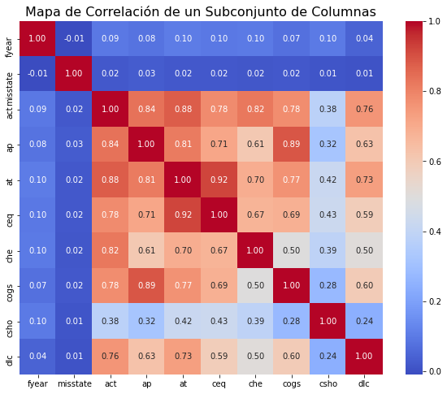

```python
# Seleccionar las columnas de interés (por ejemplo, las primeras 10 columnas)
columns_of_interest = data.iloc[:, :10]  # Esto selecciona las primeras 10 columnas
# Calcular la matriz de correlación para el subconjunto de columnas
correlation_matrix = columns_of_interest.corr()
# Crear un mapa de calor de la matriz de correlación
plt.figure(figsize=(10, 8))  # Tamaño del gráfico
sns.heatmap(correlation_matrix, annot=True, cmap='coolwarm', fmt=".2f")
plt.title('Mapa de Correlación de un Subconjunto de Columnas', fontsize=16)
plt.show()
```

```python
#Guardamos el dataset- Hacemos una clasificacion binaria.
data.to_csv('fraude1.csv', index=False)
```

# Nuevo conjunto de datos fraude1

```python
data1 = pd.read_csv('fraude1.csv')
data1.sample(10)
```

|  | fyear | misstate | act | ap | at | ceq | che | cogs | csho | dlc | ... | soft_assets | ch_cs | ch_cm | ch_roa | issue | bm | dpi | reoa | EBIT | ch_fcf |
| --- | --- | --- | --- | --- | --- | --- | --- | --- | --- | --- | --- | --- | --- | --- | --- | --- | --- | --- | --- | --- | --- |
| 55895 | 2002 | 0 | 3.446 | 0.536 | 3.993 | -0.103 | 0.000 | 5.056 | 13.543 | 1.208 | ... | 0.993599 | 0.067918 | -0.023205 | -0.001893 | 1 | -0.050703 | 1.523810 | -0.293514 | 0.134235 | -0.117913 |
| 33881 | 2009 | 0 | 7.251 | 0.636 | 16.173 | 6.601 | 2.598 | 3.716 | 36.069 | 0.640 | ... | 0.757992 | 0.117218 | 0.032921 | 0.222613 | 1 | 0.285954 | 0.919936 | -11.040376 | -0.150312 | 0.429637 |
| 13942 | 1990 | 0 | 408.098 | 75.857 | 1427.956 | 331.138 | 72.220 | 1184.184 | 98.411 | 16.827 | ... | 0.513947 | 0.241935 | 1.043499 | -0.045145 | 1 | 0.292595 | 1.017756 | 0.166557 | 0.171642 | -0.030490 |
| 65129 | 2007 | 0 | 30.910 | 7.774 | 36.107 | 6.746 | 0.623 | 58.305 | 4.638 | 18.324 | ... | 0.932894 | 0.129942 | -0.116523 | -0.030724 | 1 | 1.077412 | 0.982709 | -0.117983 | 0.043094 | -0.023025 |
| 109754 | 2002 | 0 | 23.241 | 2.094 | 28.909 | 20.479 | 6.352 | 41.797 | 10.488 | 0.000 | ... | 0.613304 | 0.168024 | -0.050178 | -0.085058 | 1 | 0.078862 | 1.010561 | 0.118821 | 0.437407 | -0.160832 |
| 124874 | 2007 | 0 | 13.801 | 2.118 | 14.133 | 10.343 | 10.777 | 31.949 | 4.114 | 0.000 | ... | 0.219274 | 0.197614 | -1.248533 | 0.472312 | 1 | 0.279655 | 0.943349 | -13.411095 | 0.174485 | 0.387653 |
| 117179 | 2005 | 0 | 5.896 | 2.010 | 44.211 | 29.778 | 1.431 | 6.680 | 8.591 | 0.000 | ... | 0.102260 | 0.517043 | -0.241501 | -0.041195 | 1 | 0.169911 | 1.093666 | 0.154215 | 0.135939 | -0.190290 |
| 141369 | 1995 | 0 | 24.877 | 4.598 | 63.864 | 31.192 | 6.212 | 19.324 | 5.361 | 10.449 | ... | 0.853376 | -0.056223 | -0.499159 | -0.085265 | 1 | 0.612454 | 0.521062 | 0.326475 | 0.054162 | -0.058886 |
| 143938 | 1998 | 0 | 4.955 | 2.117 | 28.333 | 10.281 | 0.699 | 6.916 | 21.253 | 3.906 | ... | 0.605866 | 1.887933 | 0.426398 | -0.212691 | 1 | 0.703627 | 0.287073 | -0.975647 | -0.181837 | -0.166653 |
| 30691 | 2007 | 0 | 450.623 | 90.866 | 547.067 | 262.578 | 139.631 | 905.671 | 40.342 | 0.375 | ... | 0.705570 | 0.041361 | 0.068156 | -0.001645 | 1 | 0.509296 | 1.012787 | -0.118552 | 0.097175 | 0.066645 |

10 rows × 44 columns

```python
#Separamos variables independintes(X) y dependientes(y)
X_features = data1.drop(['misstate'],axis=1)
y_target = data1['misstate']
```

# Datos de entrenamiento y prueba

```python
from sklearn.model_selection import train_test_split

X_train,X_test,y_train,y_test = train_test_split(X_features,y_target,test_size=0.2,random_state=21)
```

Los datos de la prueba se toman por defecto como 20% de los datos originales, a menos que se especifique otro valor. Por lo tanto, el valor de entrenamiento será el 80% de los datos originales y el valor de prueba será el 20% de los datos originales

```python
X_train
```

|  | fyear | act | ap | at | ceq | che | cogs | csho | dlc | dltis | ... | soft_assets | ch_cs | ch_cm | ch_roa | issue | bm | dpi | reoa | EBIT | ch_fcf |
| --- | --- | --- | --- | --- | --- | --- | --- | --- | --- | --- | --- | --- | --- | --- | --- | --- | --- | --- | --- | --- | --- |
| 98686 | 2008 | 58.364 | 2.260 | 61.475 | 45.958 | 57.743 | 56.244 | 17.836 | 2.060 | 8.250 | ... | 0.023131 | -0.388562 | 1.956369 | -0.422954 | 1 | 0.215263 | 1.173867 | -5.146873 | -0.891094 | -0.285616 |
| 84763 | 2001 | 0.426 | 0.396 | 0.479 | 0.025 | 0.078 | 0.234 | 63.693 | 0.000 | 0.000 | ... | 0.726514 | -0.148450 | 0.840059 | -0.600167 | 1 | 0.003925 | 1.069979 | -15.590814 | -1.979123 | -1.311085 |
| 145488 | 2006 | 34.814 | 0.814 | 44.775 | 43.274 | 16.680 | 5.721 | 61.099 | 0.000 | 0.000 | ... | 0.623585 | -0.723323 | 1.140753 | 1.047060 | 1 | 0.378749 | 0.616716 | -3.698314 | -0.056281 | 0.929513 |
| 21316 | 1995 | 5.442 | 1.200 | 7.709 | 3.792 | 0.899 | 8.826 | 14.100 | 1.276 | 0.049 | ... | 0.687119 | -0.045112 | -0.010768 | -0.026021 | 1 | 0.179291 | 0.878148 | 0.442600 | 0.042548 | -0.085921 |
| 41306 | 1991 | 0.183 | 0.929 | 3.417 | -3.562 | 0.038 | 0.626 | 49.502 | 3.206 | 0.384 | ... | 0.817969 | -0.321311 | 0.959617 | 0.249165 | 1 | -2.321184 | 0.478596 | -6.631255 | -0.251975 | 0.709076 |
| ... | ... | ... | ... | ... | ... | ... | ... | ... | ... | ... | ... | ... | ... | ... | ... | ... | ... | ... | ... | ... | ... |
| 63856 | 2007 | 21.356 | 10.868 | 339.240 | 228.407 | 16.065 | 19.629 | 261.657 | 0.000 | 0.000 | ... | 0.017675 | -0.555548 | -2.469907 | 0.034533 | 1 | 0.382862 | 4.036458 | -0.890832 | -0.050702 | -0.124459 |
| 81968 | 1991 | 37.340 | 20.193 | 47.679 | 11.340 | 0.715 | 5.991 | 6.438 | 11.679 | 0.000 | ... | 0.890392 | -0.807507 | -0.501054 | 0.021324 | 0 | 1.761417 | 0.778040 | -0.043751 | -0.089956 | 0.259145 |
| 140036 | 1992 | 5.819 | 2.132 | 8.943 | 0.389 | 0.630 | 9.438 | 6.539 | 3.858 | 2.872 | ... | 0.885497 | 0.681331 | -0.289181 | -0.101939 | 1 | 0.045342 | 1.515013 | -1.080510 | -0.466398 | -0.186746 |
| 70863 | 1995 | 11.104 | 1.416 | 48.828 | 18.909 | 8.983 | 6.876 | 24.544 | 0.000 | 0.000 | ... | 0.050872 | 0.162243 | -0.008434 | 0.006046 | 1 | 0.397530 | 1.041745 | -0.500717 | 0.045630 | 0.010645 |
| 80841 | 2010 | 44.179 | 41.610 | 413.462 | 205.611 | 20.271 | 53.416 | 109.718 | 36.295 | 73.792 | ... | 0.180258 | 1.149091 | -0.252427 | 0.013250 | 1 | 0.309240 | 0.611507 | -0.028491 | 0.056477 | -0.040515 |

116836 rows × 43 columns

# Homgenización de variables

Se usaron técnicas para homogeneizar los datos, puesto que nuestras características tienen diferentes escalas, las técnicas se usaron para no introducir sesgos en los modelos y lograr que las características tengan el mismo peso dentro del modelo y el peso tome la verdadera relevancia o no.

# Escalado estandar

```python
from sklearn.preprocessing import StandardScaler
# revisar MinMaxScaler
#from sklearn.preprocessing import StandardScaler

scaler = StandardScaler()
X_train = scaler.fit_transform(X_train)
X_test = scaler.transform(X_test)

X_train = pd.DataFrame(X_train, columns=X_features.columns)
X_test = pd.DataFrame(X_test, columns=X_features.columns)
```

```python
display(X_train.head())
display(X_test.head())
```

|  | fyear | act | ap | at | ceq | che | cogs | csho | dlc | dltis | ... | soft_assets | ch_cs | ch_cm | ch_roa | issue | bm | dpi | reoa | EBIT | ch_fcf |
| --- | --- | --- | --- | --- | --- | --- | --- | --- | --- | --- | --- | --- | --- | --- | --- | --- | --- | --- | --- | --- | --- |
| 0 | 0.859201 | -0.181964 | -0.170146 | -0.193676 | -0.166764 | -0.120842 | -0.156830 | -0.186501 | -0.124550 | -0.119454 | ... | -1.743077 | -0.427447 | 0.765513 | -1.137408 | 0.397949 | -0.191547 | 0.283239 | -0.150862 | -0.615005 | -0.513180 |
| 1 | -0.146414 | -0.197638 | -0.171916 | -0.198810 | -0.175951 | -0.164940 | -0.163905 | -0.077008 | -0.126623 | -0.124578 | ... | 0.827489 | -0.244284 | 0.347013 | -1.625194 | 0.397949 | -0.352354 | 0.066772 | -0.956703 | -1.640759 | -2.413139 |
| 2 | 0.571883 | -0.188335 | -0.171519 | -0.195082 | -0.167301 | -0.152244 | -0.163212 | -0.083201 | -0.126623 | -0.124578 | ... | 0.451327 | -0.682810 | 0.459742 | 2.908854 | 0.397949 | -0.067150 | -0.877680 | -0.039093 | 0.172025 | 1.738174 |
| 3 | -1.008369 | -0.196281 | -0.171153 | -0.198201 | -0.175198 | -0.164313 | -0.162819 | -0.195421 | -0.125339 | -0.124548 | ... | 0.683518 | -0.165455 | 0.028042 | -0.044838 | 0.397949 | -0.218918 | -0.332942 | 0.280414 | 0.265197 | -0.143191 |
| 4 | -1.583006 | -0.197704 | -0.171410 | -0.198563 | -0.176668 | -0.164971 | -0.163855 | -0.110892 | -0.123397 | -0.124339 | ... | 1.161720 | -0.376146 | 0.391835 | 0.712622 | 0.397949 | -2.121531 | -1.165475 | -0.265395 | -0.012468 | 1.329756 |

5 rows × 43 columns

|  | fyear | act | ap | at | ceq | che | cogs | csho | dlc | dltis | ... | soft_assets | ch_cs | ch_cm | ch_roa | issue | bm | dpi | reoa | EBIT | ch_fcf |
| --- | --- | --- | --- | --- | --- | --- | --- | --- | --- | --- | --- | --- | --- | --- | --- | --- | --- | --- | --- | --- | --- |
| 0 | -0.577391 | -0.134562 | -0.158413 | -0.174920 | -0.131855 | -0.069777 | -0.144724 | -0.165670 | -0.126614 | -0.124578 | ... | -0.183615 | 0.139137 | 0.067905 | 0.235078 | 0.397949 | -0.211769 | -0.355640 | 0.267410 | 0.398936 | -0.248552 |
| 1 | 0.284564 | -0.181117 | -0.168215 | -0.189365 | -0.157919 | -0.137223 | -0.160007 | -0.153044 | -0.126030 | -0.124578 | ... | -0.005431 | -0.140693 | 0.104220 | -0.664469 | 0.397949 | 0.068807 | -0.031033 | 0.203014 | 0.179901 | -0.109232 |
| 2 | -0.002754 | -0.196065 | -0.169885 | -0.194010 | -0.174341 | -0.162702 | -0.163628 | -0.170197 | -0.126411 | -0.117882 | ... | 0.768184 | -0.280454 | -0.036797 | -0.541968 | 0.397949 | -0.259549 | 6.247942 | 0.126836 | -0.128347 | -0.298355 |
| 3 | 0.428224 | -0.160109 | -0.154336 | -0.169600 | -0.122334 | -0.106862 | -0.154652 | -0.113664 | -0.126623 | -0.124578 | ... | 0.476915 | 0.066828 | 0.038581 | 0.053885 | 0.397949 | -0.234766 | -0.150606 | 0.306800 | 0.523931 | -0.661764 |
| 4 | 1.290179 | -0.158432 | -0.143614 | -0.035311 | -0.006694 | -0.159255 | -0.155480 | -0.120471 | -0.121848 | 0.132569 | ... | -1.530503 | -0.218979 | -0.010564 | -0.151832 | 0.397949 | 2.320656 | -0.649965 | 0.252465 | 0.146061 | -0.026313 |

5 rows × 43 columns

# Implementación de Método

### Llamar al método LogisticRegression

```python
from sklearn.metrics import accuracy_score
from sklearn.linear_model import LogisticRegression
logreg = LogisticRegression()
```

Fit the model Entranamiento del modelo significa que estás haciendo que tu algoritmo aprenda la relación entre las características y los objetivos para que puedas predecir los valores futuros del resultado.

```python
logreg.fit(X_train, y_train)
```

```
LogisticRegression()
```

# Predicción para el conjunto de datos de prueba

```python
Y_pred = logreg.predict(X_test)
Y_pred
```

```
array([0, 0, 0, ..., 0, 0, 0], dtype=int64)
```

# Puntuación de precisión y matriz de confusión

```python
log_train = round(logreg.score(X_train, y_train) * 100, 2)
log_accuracy = round(accuracy_score(Y_pred, y_test) * 100, 2)
print("Training Accuracy    :",log_train)
print("Model Accuracy Score :",log_accuracy)
```

```
Training Accuracy    : 99.35
Model Accuracy Score : 99.3
```

# Matriz de confusion

```python
pred_results1 = pd.DataFrame({'y_test': y_test,
                             'Y_pred': Y_pred})
pred_results1.head()
```

|  | y_test | Y_pred |
| --- | --- | --- |
| 127966 | 0 | 0 |
| 105164 | 0 | 0 |
| 48802 | 0 | 0 |
| 116242 | 0 | 0 |
| 26701 | 0 | 0 |

Podríamos averiguar el reparto de muestras resultante de cruzar los campos de predicción de resulatdos "Predición" y "Muestras de variable Hipotesis" con la siguiente instrucción:

```python
data_crosstab = pd.crosstab(pred_results1.Y_pred, pred_results1.y_test)
data_crosstab
```

| y_test Y_pred | 0 | 1 |
| --- | --- | --- |
| 0 | 29003 | 202 |
| 1 | 3 | 1 |

# Kneighbors

```python
from sklearn.neighbors import KNeighborsClassifier
knn = KNeighborsClassifier(n_neighbors = 3)
knn.fit(X_train, y_train)
Y_pred = knn.predict(X_test)

knn_train = round(knn.score(X_train, y_train) * 100, 2)
knn_accuracy = round(accuracy_score(Y_pred, y_test) * 100, 2)

print("Training Accuracy     :",knn_train)
print("Model Accuracy Score  :",knn_accuracy)
```

```
Training Accuracy     : 99.43
Model Accuracy Score  : 99.28
```

```python
pred_results2 = pd.DataFrame({'y_test': y_test,
                             'Y_pred': Y_pred})
pred_results2.head()
```

|  | y_test | Y_pred |
| --- | --- | --- |
| 127966 | 0 | 0 |
| 105164 | 0 | 0 |
| 48802 | 0 | 0 |
| 116242 | 0 | 0 |
| 26701 | 0 | 0 |

# Gaussian Naive Bayes

```python
# Gaussian Naive Bayes
from sklearn.naive_bayes import GaussianNB
gaussian = GaussianNB()
gaussian.fit(X_train, y_train)
Y_pred = gaussian.predict(X_test)

gaussian_train = round(gaussian.score(X_train, y_train) * 100, 2)
gaussian_accuracy = round(accuracy_score(Y_pred, y_test) * 100, 2)

print("Training Accuracy     :",gaussian_train)
print("Model Accuracy Score  :",gaussian_accuracy)
```

```
Training Accuracy     : 96.14
Model Accuracy Score  : 96.21
```

```python
pred_results3 = pd.DataFrame({'y_test': y_test,
                             'Y_pred': Y_pred})
pred_results3.head()
```

[output not shown]

# Random Forest Regressor

```python
from sklearn.ensemble import RandomForestRegressor
#Definirmos el Método a implementar
RF = RandomForestRegressor()
#Entrenar el modelos juntos con los datos de entrenamiento y el método
RF.fit(X_train, y_train)
```

```
RandomForestRegressor()
```

```python
#realizar una prediccion para ver que tal es el modelo que se construyo
y_train_pred = RF.predict(X_train)
y_test_pred = RF.predict(X_test)
```

# Error promedio al cuadrado

```python
from sklearn.metrics import mean_squared_error
from sklearn.metrics import r2_score

# aplicando metrica de Error promedio al cuadrado. Esta metrica es bueno si el Numro esta cercano al 0
rmse_rf = (mean_squared_error(y_test,y_test_pred))**(1/2)
print('Error promedio al cuadrado :', rmse_rf)

#calculo R2 #un buen resulatdo es mas cercano al uno mucho mejor
print('R2 :', r2_score(y_test, y_test_pred))

#*** Se obsrev que el modelo es regular***
```

```
Error promedio al cuadrado : 0.08029254685772348
R2 : 0.06588582051479785
```